# s01_check_duplicates

started: AL07Dec2018  
last updated: AL30Sep2019

# Summary

Check concordance rates for common variants in each-to-each-case basis  
The purpose is to find the intentional duplicates introduced for QC purposes

Detected 11 pairs of intended QC duplicates (identical to wecare-nfe analysis):

40_S189_L007 - 41_S328_L008  
76_S299_L008 - 77_S370_L008  
234_S381_L008 - 235_S535_L008  
244_S175_L007 - 245_S59_L007  
280_S173_L007 - 281_S185_L007 **both should be keept as explained by US collaborators**  
347_S36_L007 - 348_S17_L007  
398_S161_L007 - 399_S255_L007  
436_S178_L007 - 437_S177_L007  
517_S450_L008 - 518_S384_L008  
527_S233_L007 - 528_S275_L008  
539_S288_L008 - 540_S461_L008

and 2 pairs of additional duplicates (with distinct phenotypes):

270_S70_L007 - 351_S71_L007 **are located near each other on the plate**  
386_S273_L008 - 391_S376_L008

One pair of intended duplicates was not detected because  
a sample from this pair failed sequencing (108):  
108_S482_L008 - 109_S484_L008

Input data: 3,758 vars x 535 samples (265UBC + 270CBC)  
No output data

# start section

```r
Sys.time()
```

```
## [1] "2019-09-30 17:31:53 BST"
```

```r
rm(list=ls())
graphics.off()

library(knitr)
library(dplyr)
library(ggplot2)
base_folder="/Users/alexey/Documents/wecare/ampliseq/v05_ampliseq_only/s10_remove_duplicates"
opts_knit$set(root.dir = base_folder)

options(stringsAsFactors = F)
options(warnPartialMatchArgs = T,
        warnPartialMatchAttr = T,
        warnPartialMatchDollar = T)

#options(error = browser()) # Type Q or c to exit, drop browser level
# https://support.rstudio.com/hc/en-us/articles/200713843?version=1.1.456&mode=desktop
# https://stackoverflow.com/questions/13052522/how-to-leave-the-r-browser-mode-in-the-console-window/13052588
```

# read data

```r
source_folder="/Users/alexey/Documents/wecare/ampliseq/v05_ampliseq_only/s09_add_phenotypes"
load(paste(source_folder, "s01_add_phenotypes.RData", sep="/"))
base_folder="/Users/alexey/Documents/wecare/ampliseq/v05_ampliseq_only/s10_remove_duplicates"
rm(source_folder)
```

# Check data

```r
ls()
```

```
## [1] "base_folder"   "genotypes.mx"  "phenotypes.df" "variants.df"
```

```r
dim(genotypes.mx)
```

```
## [1] 3758  535
```

```r
dim(phenotypes.df)
```

```
## [1] 535  24
```

```r
dim(variants.df)
```

```
## [1] 3758   65
```

```r
sum(colnames(genotypes.mx) != rownames(phenotypes.df))
```

```
## [1] 0
```

```r
sum(rownames(genotypes.mx) != rownames(variants.df))
```

```
## [1] 0
```

# Calculate concordance matrix

Use common variants only

```r
# Remove common variants
common_vars <- variants.df$init_AF >= 0.05 & variants.df$init_AF <= 0.95
sum(common_vars)
```

```
## [1] 482
```

```r
gt_com.mx <- genotypes.mx[common_vars,]
dim(gt_com.mx)
```

```
## [1] 482 535
```

```r
# Initialise concordance matrix
conc.mx <- matrix(NA, ncol=ncol(gt_com.mx), nrow=ncol(gt_com.mx))
colnames(conc.mx) <- colnames(gt_com.mx)
rownames(conc.mx) <- colnames(gt_com.mx)
conc.mx[1:5,1:5]
```

```
##               100_S8_L007 101_S528_L008 102_S466_L008 103_S147_L007 104_S325_L008
## 100_S8_L007            NA            NA            NA            NA            NA
## 101_S528_L008          NA            NA            NA            NA            NA
## 102_S466_L008          NA            NA            NA            NA            NA
## 103_S147_L007          NA            NA            NA            NA            NA
## 104_S325_L008          NA            NA            NA            NA            NA
```

```r
# Initialise counts matrix
cnts.mx <- matrix(NA, ncol=ncol(gt_com.mx), nrow=ncol(gt_com.mx))
colnames(cnts.mx) <- colnames(gt_com.mx)
rownames(cnts.mx) <- colnames(gt_com.mx)
cnts.mx[1:5,1:5]
```

```
##               100_S8_L007 101_S528_L008 102_S466_L008 103_S147_L007 104_S325_L008
## 100_S8_L007            NA            NA            NA            NA            NA
## 101_S528_L008          NA            NA            NA            NA            NA
## 102_S466_L008          NA            NA            NA            NA            NA
## 103_S147_L007          NA            NA            NA            NA            NA
## 104_S325_L008          NA            NA            NA            NA            NA
```

```r
# Calculate concordances
for(sample_1 in colnames(gt_com.mx)){
  for(sample_2 in colnames(gt_com.mx)){

    # Get vectors of variants for both samples
    smp1 <- gt_com.mx[,sample_1]
    smp2 <- gt_com.mx[,sample_2]

    # Calculate concordance
    total <- sum(!is.na(smp1) & !is.na(smp2))
    concordant <- sum(smp1==smp2, na.rm=T)
    concordance_rate <- concordant / total

    # Write result
    if(sample_1 == sample_2){
      NA  -> cnts.mx[sample_1,sample_2]
      NA  -> conc.mx[sample_1,sample_2]
    }else{
      total -> cnts.mx[sample_1,sample_2]
      concordance_rate -> conc.mx[sample_1,sample_2]
    }
  }
}

# Check results
cnts.mx[1:5,1:5]
```

```
##               100_S8_L007 101_S528_L008 102_S466_L008 103_S147_L007 104_S325_L008
## 100_S8_L007            NA           441           363           361           454
## 101_S528_L008         441            NA           366           365           457
## 102_S466_L008         363           366            NA           329           367
## 103_S147_L007         361           365           329            NA           365
## 104_S325_L008         454           457           367           365            NA
```

```r
conc.mx[1:5,1:5]
```

```
##               100_S8_L007 101_S528_L008 102_S466_L008 103_S147_L007 104_S325_L008
## 100_S8_L007            NA     0.5260771     0.5482094     0.4847645     0.5550661
## 101_S528_L008   0.5260771            NA     0.5765027     0.5808219     0.6017505
## 102_S466_L008   0.5482094     0.5765027            NA     0.5562310     0.5149864
## 103_S147_L007   0.4847645     0.5808219     0.5562310            NA     0.5643836
## 104_S325_L008   0.5550661     0.6017505     0.5149864     0.5643836            NA
```

```r
# Clean-up
rm(common_vars, gt_com.mx, sample_1, sample_2, smp1, smp2,
   total, concordant, concordance_rate)
```

# Explore concordance matrix

```r
# No missed values (except self-concordance/count)
dim(cnts.mx)
```

```
## [1] 535 535
```

```r
sum(is.na(cnts.mx))
```

```
## [1] 535
```

```r
sum(is.na(conc.mx))
```

```
## [1] 535
```

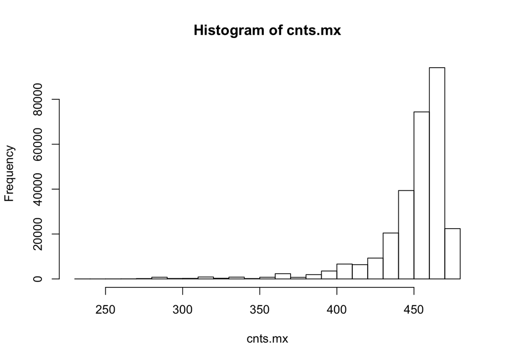

```r
# Histograms

hist(cnts.mx)
```

```r
quantile(cnts.mx, na.rm=T)
```

```
##   0%  25%  50%  75% 100%
##  231  446  458  465  480
```

```r
mean(cnts.mx, na.rm=T)
```

```
## [1] 450.3961
```

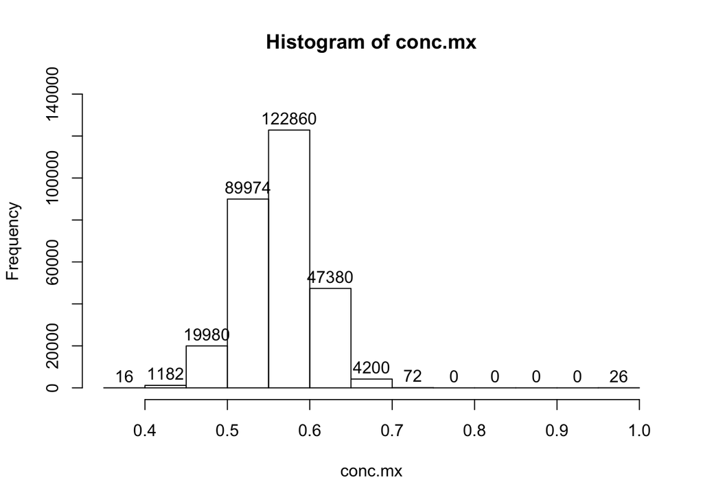

```r
hist(conc.mx, ylim=c(0,140000), lab=T)
```

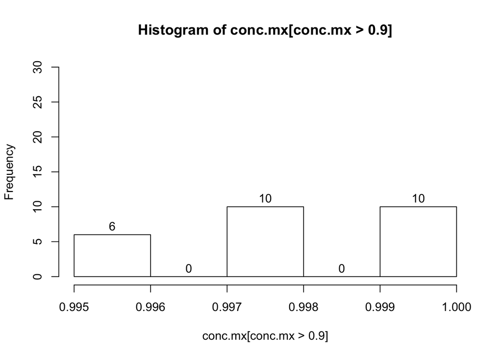

```r
hist(conc.mx[conc.mx > 0.9], lab=T, ylim=c(0,30))
```

```r
sum(conc.mx == 1, na.rm=T)
```

```
## [1] 10
```

```r
# Make list of most similar samples (concordance > 0.9)
conc_cases.mx <- matrix(nrow=0, ncol=4)
c("sample_1","sample_2","count","concordance") -> colnames(conc_cases.mx)
for(sample_1 in rownames(conc.mx)){
  for(sample_2 in colnames(conc.mx)){
    if(sample_1!=sample_2 & conc.mx[sample_1,sample_2] > 0.9 ){
      conc_cases.mx <- rbind(conc_cases.mx, c(sample_1,sample_2,
                                              cnts.mx[sample_1,sample_2],
                                              conc.mx[sample_1,sample_2]))
    }
  }
}

# Check result
conc_cases.mx
```

```
##       sample_1        sample_2        count concordance
##  [1,] "234_S381_L008" "235_S535_L008" "462" "1"
##  [2,] "235_S535_L008" "234_S381_L008" "462" "1"
##  [3,] "244_S175_L007" "245_S59_L007"  "414" "1"
##  [4,] "245_S59_L007"  "244_S175_L007" "414" "1"
##  [5,] "270_S70_L007"  "351_S71_L007"  "457" "1"
##  [6,] "280_S173_L007" "281_S185_L007" "462" "0.995670995670996"
##  [7,] "281_S185_L007" "280_S173_L007" "462" "0.995670995670996"
##  [8,] "347_S36_L007"  "348_S17_L007"  "456" "0.99780701754386"
##  [9,] "348_S17_L007"  "347_S36_L007"  "456" "0.99780701754386"
## [10,] "351_S71_L007"  "270_S70_L007"  "457" "1"
## [11,] "386_S273_L008" "391_S376_L008" "452" "0.995575221238938"
## [12,] "391_S376_L008" "386_S273_L008" "452" "0.995575221238938"
## [13,] "398_S161_L007" "399_S255_L007" "471" "1"
## [14,] "399_S255_L007" "398_S161_L007" "471" "1"
## [15,] "40_S189_L007"  "41_S328_L008"  "453" "0.997792494481236"
## [16,] "41_S328_L008"  "40_S189_L007"  "453" "0.997792494481236"
## [17,] "436_S178_L007" "437_S177_L007" "451" "0.995565410199557"
## [18,] "437_S177_L007" "436_S178_L007" "451" "0.995565410199557"
## [19,] "517_S450_L008" "518_S384_L008" "468" "0.997863247863248"
## [20,] "518_S384_L008" "517_S450_L008" "468" "0.997863247863248"
## [21,] "527_S233_L007" "528_S275_L008" "457" "0.99781181619256"
## [22,] "528_S275_L008" "527_S233_L007" "457" "0.99781181619256"
## [23,] "539_S288_L008" "540_S461_L008" "458" "1"
## [24,] "540_S461_L008" "539_S288_L008" "458" "1"
## [25,] "76_S299_L008"  "77_S370_L008"  "461" "0.997830802603037"
## [26,] "77_S370_L008"  "76_S299_L008"  "461" "0.997830802603037"
```

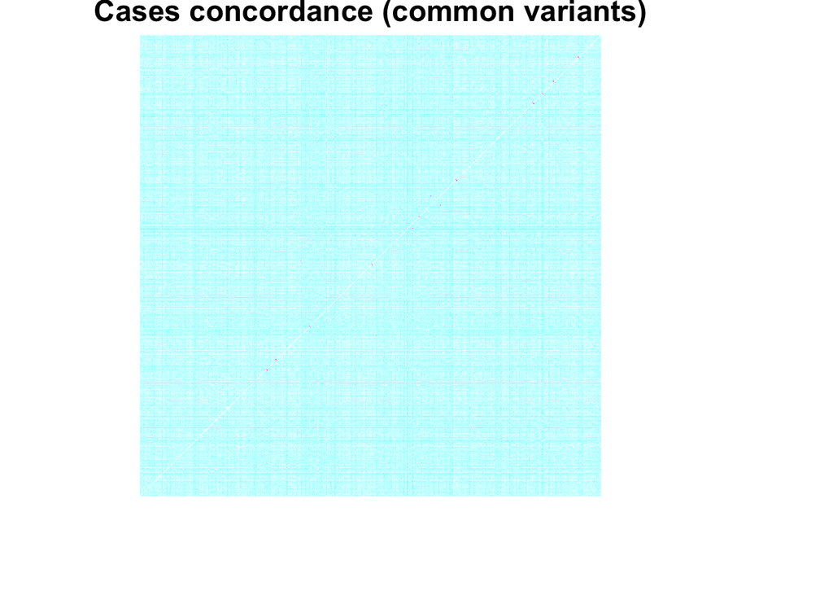

```r
# Heatmaps
heatmap(conc.mx, Rowv=NA, Colv=NA, scale='none',
        col = cm.colors(256), labRow=NA, labCol = NA,
        main="Cases concordance (common variants)")
```

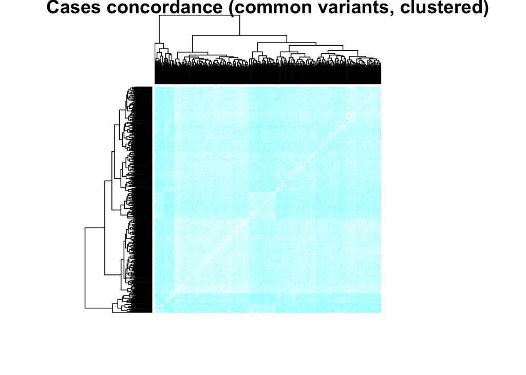

```r
heatmap(conc.mx, scale='none',
        col = cm.colors(256), labRow=NA, labCol = NA,
        main="Cases concordance (common variants, clustered)")
```

```r
# Clean-up
rm(sample_1, sample_2)
```

# Check phenotypes annotations in concordant cases

## Expected duplicates

Phenotype records for expected duplicates are identical,  
except for one case, which is intentionally used twice in different capacities  
(once as case and once as control)

```r
dim(phenotypes.df)
```

```
## [1] 535  24
```

```r
colnames(phenotypes.df)
```

```
##  [1] "long_ids"         "illumina_id"      "illumina_lane"    "Sample_num"       "cc"               "rstime"           "sub_dx_age"       "hormone_self_mra" "chemo_self_mra"   "treatment"        "Hist_lob_other"   "stage_fd"         "histo1_cat"       "er1_cat"          "pr1_cat"          "grade1…
```

```r
x <- phenotypes.df["40_S189_L007",] != phenotypes.df["41_S328_L008",]
sum(x[5:24]) # exclude long_ids illumina_id illumina_lane Sample_num fields
```

```
## [1] 0
```

```r
x <- phenotypes.df["76_S299_L008",] != phenotypes.df["77_S370_L008",]
sum(x[5:24]) # exclude long_ids illumina_id illumina_lane Sample_num fields
```

```
## [1] 0
```

```r
x <- phenotypes.df["234_S381_L008",] != phenotypes.df["235_S535_L008",]
sum(x[5:24]) # exclude long_ids illumina_id illumina_lane Sample_num fields
```

```
## [1] 0
```

```r
x <- phenotypes.df["244_S175_L007",] != phenotypes.df["245_S59_L007",]
sum(x[5:24]) # exclude long_ids illumina_id illumina_lane Sample_num fields
```

```
## [1] 0
```

```r
x <- phenotypes.df["280_S173_L007",] != phenotypes.df["281_S185_L007",]
sum(x[5:24]) # exclude long_ids illumina_id illumina_lane Sample_num fields
```

```
## [1] 3
```

```r
phenotypes.df[c("280_S173_L007","281_S185_L007"),x]
```

```
##                    long_ids illumina_id Sample_num cc rstime  setno
## 280_S173_L007 280_S173_L007        S173        280  0   5.92 269688
## 281_S185_L007 281_S185_L007        S185        281  1   7.33 342191
```

```r
# cc and rstime differ because used in different capacity for different pairs
# **both samples should be keept in analysis**

x <- phenotypes.df["347_S36_L007",] != phenotypes.df["348_S17_L007",]
sum(x[5:24]) # exclude long_ids illumina_id illumina_lane Sample_num fields
```

```
## [1] 0
```

```r
x <- phenotypes.df["398_S161_L007",] != phenotypes.df["399_S255_L007",]
sum(x[5:24]) # exclude long_ids illumina_id illumina_lane Sample_num fields
```

```
## [1] 0
```

```r
x <- phenotypes.df["436_S178_L007",] != phenotypes.df["437_S177_L007",]
sum(x[5:24]) # exclude long_ids illumina_id illumina_lane Sample_num fields
```

```
## [1] 0
```

```r
x <- phenotypes.df["517_S450_L008",] != phenotypes.df["518_S384_L008",]
sum(x[5:24]) # exclude long_ids illumina_id illumina_lane Sample_num fields
```

```
## [1] 0
```

```r
x <- phenotypes.df["527_S233_L007",] != phenotypes.df["528_S275_L008",]
sum(x[5:24]) # exclude long_ids illumina_id illumina_lane Sample_num fields
```

```
## [1] 0
```

```r
x <- phenotypes.df["539_S288_L008",] != phenotypes.df["540_S461_L008",]
sum(x[5:24]) # exclude long_ids illumina_id illumina_lane Sample_num fields
```

```
## [1] 0
```

## Unexpected duplicates

```r
x <- phenotypes.df["270_S70_L007",] != phenotypes.df["351_S71_L007",]
sum(x[5:21]) # exclude long_ids illumina_id illumina_lane Sample_num fields
```

```
## [1] 6
```

```r
phenotypes.df[c("270_S70_L007","351_S71_L007"),x]
```

```
##                  long_ids illumina_id Sample_num cc rstime sub_dx_age  pr1_cat Num_ftp_fd num_ftp_rd  setno xrtbreast
## 270_S70_L007 270_S70_L007         S70        270  1   5.00         50 negative          4          4 230845         0
## 351_S71_L007 351_S71_L007         S71        351  0   4.08         53 positive          2          2 217302         1
```

```r
x <- phenotypes.df["386_S273_L008",] != phenotypes.df["391_S376_L008",]
sum(x[5:21]) # exclude long_ids illumina_id illumina_lane Sample_num fields
```

```
## [1] 10
```

```r
phenotypes.df[c("386_S273_L008","391_S376_L008"),x]
```

```
##                    long_ids illumina_id Sample_num cc rstime sub_dx_age hormone_self_mra chemo_self_mra treatment Hist_lob_other stage_fd histo1_cat Lnsum1_cat  setno xrtbreast
## 386_S273_L008 386_S273_L008        S273        386  1   3.83         39                1              1         1        lobular        2    lobular   positive 280739         0
## 391_S376_L008 391_S376_L008        S376        391  0   7.00         54                0              0         0          other        1     ductal   negative 335915         1
```

```r
rm(x)
```

# final_section

```r
ls()
```

```
## [1] "base_folder"   "cnts.mx"       "conc_cases.mx" "conc.mx"       "genotypes.mx"  "phenotypes.df" "variants.df"
```

```r
Sys.time()
```

```
## [1] "2019-09-30 17:32:16 BST"
```